# Problem 2: Structure of the Universe

Authors

Lucca Braudagan

Gabriella Weis

Published

April 28, 2025

### Introduction and Conversions

For this problem, we’ve been tasked with trying to solve for Hubble’s constant– whether it be constant or changing –and the parameters it depends on. We will use the data “Hubble.csv” to do so, which contains redshift and distance information for approximately 1700 galaxies and supernova. We will also make use of the Metropolis-Hastings Algorithm and Bayes’ Law.

We will be using Python for this problem, so we begin by importing the necessary libraries: `pandas` to create data frames, `numpy` for math such as random and infinity, `emcee` for MCMC modeling, `matplotlib` for graphing, `corner` for graphing multiple histograms, and the `calc_distance` model from `models.py`.

```python
import pandas as pd
import numpy as np
import emcee
import matplotlib.pyplot as plt
from matplotlib.lines import Line2D
import corner
from models import calc_distance
```

We also loaded in the data and named it `df` for simplicity’s sake. Taking a quick look at it reveals the existence of six columns. The first two, `CID` and `IDSURVEY`, are mostly insignificant in our case because they refer to object IDs. However, the last four are very important. We have `z` (which contains redshift data), `z_ERR` (which contains the redshift uncertainty), `MU` (which contains distances as distance moduli: μ), and `MU_ERR` (which contains the μ uncertainty). We will need the `z` for calculating velocities (in kilometers per second) and `MU` for calculating distances (in megaparsecs). These will both be used to estimate Hubble’s constant. We will also need both error values for implementing our log Likelihoods.

```python
df = pd.read_csv("data/Hubble.csv")
df.head()
```

|  | CID | IDSURVEY | z | z_ERR | MU | MU_ERR |
| --- | --- | --- | --- | --- | --- | --- |
| 0 | 2011fe | 51 | 0.00122 | 0.00084 | 28.9987 | 1.516450 |
| 1 | 2011fe | 56 | 0.00122 | 0.00084 | 29.0559 | 1.517470 |
| 2 | 2012cg | 51 | 0.00256 | 0.00084 | 30.7233 | 0.782372 |
| 3 | 2012cg | 56 | 0.00256 | 0.00084 | 30.7449 | 0.799068 |
| 4 | 1994DRichmond | 50 | 0.00299 | 0.00084 | 30.7757 | 0.881212 |

Before we began, we also set a random seed for replicable outputs using `random.seed()`.

```python
np.random.seed(0)
```

The first step in our conversions is solving for velocities in km/s. We can refer to the formula $v = cz$, where `v` represents the velocity in km/s, `c` represents the speed of light in km/s, and `z` represents the redshift. In our code, we set the speed of light as a constant and multiplied it by our `z` column in the data to create a new column called `velocity_km_per_s`.

```python
speed_of_light = 299792.458 #km/s
df['velocity_km_per_s'] = df.z * speed_of_light
```

Next is the distance conversion. We referred to the formula below, where $μ$ represents the distance moduli (the apparent magnitude minus the absolute magnitude, or $m-M$) and $d_{pc}$ represents the distance in parsecs. We will need to convert this to megaparsecs after the initial parsec conversion.

$$μ=5log_{10}(d_{pc})-5$$

In order to use this formula to solve for the distances in parsecs, we needed to rearrange it into something more manageable.

$$d_{pc}=10^{(\frac{μ+5}{5})}$$

Then we can implement this into code by substituting our `MU` column for the $μ$ value in the formula. The result is a new column in our data called `d_pc`.

```python
df['d_pc'] = 10**((df.MU+5)/5)
```

Using the conversion factor for parsecs to megaparsecs ($10^{-6}$) and the formula $d_{Mpc}=d_{pc}\times 10^{-6}$ (where $d_{Mpc}$ represents the distance in megaparsecs and $d_{pc}$ represents it in parsecs), we can convert our distances to megaparsecs. This is saved under a new column in our data labeled `d_Mpc`.

```python
df['d_Mpc'] = df.d_pc * 1E-6
```

### Part A: “Close” Objects

Now that everything has been converted into the correct units, we can proceed with the actual analysis and calculations. For Part A, we will only be looking at objects within 100 Mpc of Earth. At these distances, the changing acceleration of the universe is negligible, the relationship between redshift velocity and distance will be linear, and Hubble’s constant will be unchanging.

First, we filtered for objects within 100 Mpc of Earth using the column `d_Mpc`.

```python
fil_df = df[df["d_Mpc"] <= 100]
```

Then, we constructed a function to model this linear relationship. The formula for Hubble’s (unchanging) constant is written below, where $c$ represents the speed of light (in km/s in our case), $z$ represents the redshift, $d$ represents the distance (in Mpc in our case), and $H_0$ represents Hubble’s constant in km/s/Mpc.

$$cz=H_0d$$

Our function, called `hubble()`, will take in the speed of light (km/s), the distance (Mpc), and $H_0$ (km/s/Mpc) and return the calculated redshift.

```python
def hubble(c, d, h0):
    return (h0*d)/c # will return z
```

Next, we will set up our log Prior, Likelihood, and Posterior for Markov Chain Monte Carlo (MCMC) sampling.

Our first function is that of the log Prior. It takes in the term `param`, which will be the $H_0$, and contains a single condition: if `h0` is less than 0, the function returns `-Inf`. In other words, `h0`’s value is impossible and has zero probability under the Prior. Otherwise, the function returns 0 (1 in log-space), which corresponds to a uniform Prior over the acceptable region.

```python
def ln_prior(param):
    h0 = param
    if h0 < 0:
        return -np.inf
    return 0
```

Second is the log Likelihood, which also takes in value `param`. Using the function `hubble()`, which we created earlier, we can create our `model` (remember, `hubble()`’s output is redshift data). Then we calculate the difference between the observed redshift and the predicted redshift from the model and store them in `residuals`. This will help us understand how far off our predictions are from the actual data.

The last piece of the function involves our log Likelihood formula. We break it down into two terms (`term1` and `term2`), but the complete formula is shown below in its entirety.

- $y_i$ = observed data
- $\hat{y_i}$ = model prediction for each $y_i$
- $σ$ = the standard deviation of the error (uncertainty)
- $n$ = number of observations

$$LogL(θ) = -\frac{1}{2σ^2}\sum_{i=1}^n(y_i-\hat{y_i})^2-\frac{n}{2}log(2πσ^2)$$

$$-\frac{1}{2σ^2}\sum_{i=1}^n(y_i-\hat{y_i})^2$$

$$-\frac{n}{2}log(2πσ^2)$$

All of this is implemented into the log Likelihood function below, which returns the sum of `term1` and `term2`.

```python
def ln_likelihood(param):
    model = hubble(speed_of_light, fil_df.d_Mpc, param)
    residual = fil_df.z - model
    term1 = - 0.5 * np.log(2 * np.pi * fil_df.z_ERR ** 2)
    term2 = - 0.5 * residual ** 2 / fil_df.z_ERR**2
    return sum(term1 + term2)
```

The final log function that we must define is the log Posterior, or probability distribution (which also takes in the single `param` value for `h0`). First, it calls our `ln_prior` function, which returns 0 if `h0` is valid and `-Inf` if it’s not. If it does return `-Inf`, the `ln_pdf` also returns `-Inf`, which means that because the parameter set is invalid, it will have zero probability in the Posterior.

Next, the function computes the Likelihood based on our model’s predictions versus the actual data (using our `ln_likelihood` function) and returns the sum of the Prior and Likelihood calculations. This is the log Posterior, which tells us how probable our parameter value is, given the data and our other prior assumptions.

```python
def ln_pdf(param):
    p = ln_prior(param)
    if p == -np.inf:
        return -np.inf
    return p + ln_likelihood(param)
```

Finally, it’s time to create our MCMC chains. We set our single `h0` parameter to 65 km/s/Mpc, set the number of walkers to 20, and initialized our sampler using the `EnsembleSampler()` function from `emcee` (which takes in our number of walkers, our number of dimensions, and our log Posterior). Our `starts` are calculated using `random.normal()`, which generates a list of values centered around our parameter value and with a spread of 2 km/s/Mpc. Then, we run our sampler using the function `run_mcmc()`, which takes in `starts` and the number of iterations (as well as an optional progress bar). We ran our sampler for 1000 iterations to get an adequate amount of iterations.

```python
param = [65]
num_walkers = 20
sampler = emcee.EnsembleSampler(num_walkers, 1, ln_pdf)
starts = np.random.normal(
            loc = param,
            scale = 2,
            size = (num_walkers,1))
out = sampler.run_mcmc(starts, 1000, progress=True)
```

To plot the resulting trace plot for our `h0` parameter, we can use `matplotlib` and `get_chain()` from `emcee` (which selects all walkers from all chains for the first– and only –parameter). Our trace plot appears to have an obvious burn-in, where all walkers eventually converge around one value, which is shown on the graph with a red line (we gave a generous margin by selecting a burn-in of 100 iterations).

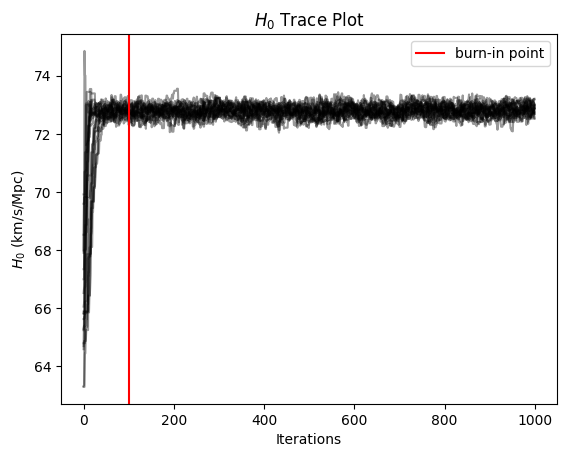

```python
plt.plot(sampler.get_chain()[:,:,0], 'k', alpha=0.4)
plt.axvline(x=100, ymin=0, ymax=1, color='red', label='burn-in point')
plt.legend()
plt.xlabel("Iterations")
plt.ylabel("$H_0$ (km/s/Mpc)")
plt.title("$H_0$ Trace Plot")
plt.show()
```

We can now cut out our burn-in and flatten all walkers into a singular chain (essentially attaching one end of each walker chain to the next and effectively stacking them). We set our burn-in to 100 (as expressed previously) and use `get_chain()` again, this time specifying `discard=burn_in` and `flat=True`.

```python
burn_in = 100
burned_in = sampler.get_chain(discard=burn_in, flat=True)
```

Next, we can create a histogram of the $H_0$ parameter’s distribution using `plt.hist()`. This creates a normal looking distribution, which is important because it has an obvious peak and it drops off on both sides. This shows that the walker explored the parameter space sufficiently.

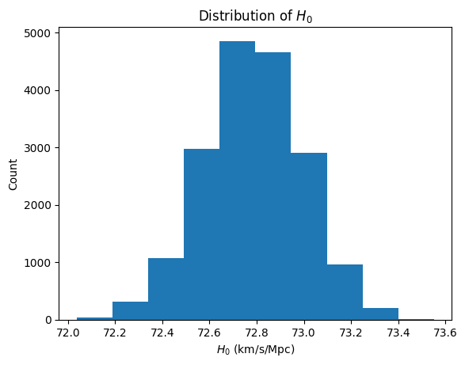

```python
plt.hist(burned_in)
plt.xlabel("$H_0$ (km/s/Mpc)")
plt.ylabel("Count")
plt.title("Distribution of $H_0$")
plt.show()
```

To extract the approximate value of $H_0$ and its uncertainty based on our post-burned-in data, we took the median and standard deviation of `burned_in` and printed those results out using f-strings.

```python
print(f"H0 Median: {np.median(burned_in)} km/s/Mpc")
print(f"H0 Standard Deviation: {np.std(burned_in)} km/s/Mpc")
```

```
H0 Median: 72.78648755891429 km/s/Mpc
H0 Standard Deviation: 0.20858337381746186 km/s/Mpc
```

The final part of Part A is randomly selecting 100 sampled (post-burn-in) Hubble constants and plotting their model results back against the nearby points on a Hubble diagram.

The result is a reasonable looking fit for our objects that are 100 Mpc away or closer.

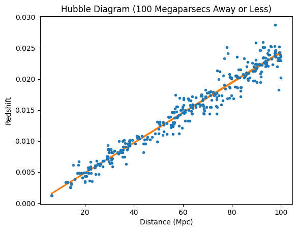

```python
for i in range(100):
    index = np.random.random_integers(0,4000)
    model = hubble(speed_of_light, fil_df.d_Mpc, burned_in[index])
    plt.plot(fil_df.d_Mpc, model, color = 'C1', alpha = 0.1)
plt.plot(fil_df.d_Mpc, fil_df.z, '.')
plt.xlabel("Distance (Mpc)")
plt.ylabel("Redshift")
plt.title("Hubble Diagram (100 Megaparsecs Away or Less)")
plt.show()
```

### Part B: All Objects

In Part A, we looked at the Hubble constant within 100 Mpc, where it remained constant. This, however, is not an accurate view, since the constant changes with distance. If we plot our $H_0$ fit for the “close” objects on a plot with *all* the data (by using the same plotting structure as Part A and replacing all `fil_df` references with `df`), we can see that, while it nicely captures linear data at small distances, objects begin to deviate from this linear trend as the distance increases. This is because the rate of the expansion of the universe has changed in the (very long) time it took for the light from these objects to reach us! It means that we have to assume the Hubble constant to be a value that has changed over the lifetime of the universe. In other words (from our perspective), the Hubble constant for objects that are closer differs from those that are farther away. The Hubble constant is no longer a constant; instead, it’s a function of $z$, or redshift.

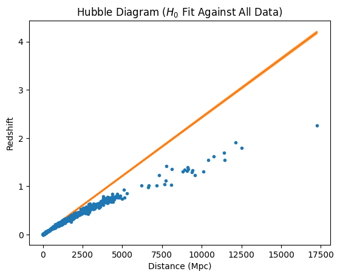

```python
for i in range(100):
    index = np.random.random_integers(0,4000)
    model = hubble(speed_of_light, df.d_Mpc, burned_in[index])
    plt.plot(df.d_Mpc, model, color = 'C1', alpha = 0.1)
plt.plot(df.d_Mpc, df.z, '.')
plt.xlabel("Distance (Mpc)")
plt.ylabel("Redshift")
plt.title("Hubble Diagram ($H_0$ Fit Against All Data)")
plt.show()
```

So, how do we implement this? The key is to integrate over all the Hubble constant’s “past” values that light has traveled through, using the formula below. Once again, $z$ represents redshift, $c$ represents the speed of light (km/s), and $d$ represents the distance (Mpc).

$$d=(1+z)c\int_{0}^{z}\frac{dz^\prime}{H(z^\prime)}$$

This allows us to compute the Hubble constant as a function of redshift, or $H(z)$, using the formula below with the following variables:

- $H_0$, which represents the value of the Hubble constant *currently*. It should be a positive value. (Units = km/s/Mpc)
- $\Omega_M$, which represents the overall matter density in the universe (both dark and light matter). It should be a value between 0 and 1. (Unitless)
- $\Omega_K$, which represents the overall curvature of the universe. The closer to 0 this value is, the flatter the universe, and higher values (negative or positive) indicate curvature. It should be a value between -1 and 1.(Unitless)
- $\Omega_\Lambda$, which reprsents the cosmological constant. It should be a value between 0 and 1. This generally represents the amount of dark energy in our universe. (Unitless)

$$H(z)=H_0\sqrt{\Omega_M(1 + z)^3 + \Omega_K(1+z)^2 + \Omega_\Lambda}$$

Also, it should be noted that $\Omega_M$, $\Omega_K$, and $\Omega_\Lambda$ are fractional proportions, meaning they should all add up to 1.

$$\Omega_M + \Omega_K + \Omega_\Lambda = 1$$

Clearly, we need a new model! To do this, we need to handle the integration specified above. Though we could use a numerical integration solver, such as `quad`, we have been provided with a pre-built model called `calc_distances()` (which we imported from `models` at the very beginning of the problem). This takes in our four parameters ($H_0$, $\Omega_M$, $\Omega_K$, and $\Omega_\Lambda$) and integrates for us, outputting a list of distances in Mpcs.

In order to create our MCMC sampler once again (this time for four parameters), we have to recreate our log Prior, Likelihood, and Posterior once again. Though they have a similar structure to what we had before, some of the values are different.

Starting with the Prior, we have to set conditions for each of our parameters. Remember, $H_0$ must be positive, $\Omega_M$ must be a value between 0 and 1, $\Omega_K$ must be a value between -1 and 1, and $\Omega_\Lambda$ must be a value between 0 and 1. All of our $\Omega$ terms should also add up to (approximately, with a bit of leeway) 1. The log Prior below reflects these conditions and functions in the same way as the Prior from Part A.

```python
def ln_prior_b(params):
    h0, om_m, om_k, om_1 = params
    if h0 < 0 or om_m < 0 or om_m > 1 or om_k < -1 or om_k > 1 \
        or om_1 < 0 or om_1 > 1 or om_m+om_k+om_1 > 1.1 or om_m+om_k+om_1 < 0.9:
        return -np.inf
    return 0
```

The result we can save as a new column in our data called `d_ERR_pc`. Then, using the conversion factor for parsecs to megaparsecs ($10^{-6}$) and the formula $d_{Mpc}=d_{pc}\times 10^{-6}$ (where $d_{Mpc}$ represents the distance in megaparsecs and $d_{pc}$ represents it in parsecs), we can convert our distance uncertainty term to megaparsecs. This is saved under a new column in our data labeled `d_ERR_Mpc`.

```python
df['d_ERR_pc'] = (np.log(10)/5) * 10**(1+(df.MU/5)) * df.MU_ERR
df['d_ERR_Mpc'] = df.d_ERR_pc * 1E-6
```

Let’s get back to the construction of our log Likelihood! Instead of using the `hubble()` function like we did in Part A, we use `calc_distance()` and the resulting `model` to calculate our distances (in Mpc). After finding the `residuals` and each term using our newly calculated `d_ERR_Mpc`, we return the sum of `term1` and `term2` as our output.

```python
def ln_likelihood_b(params):
    model = calc_distance(params, df.z)
    residual = df.d_Mpc - model
    term1 = - 0.5 * np.log(2 * np.pi * df.d_ERR_Mpc ** 2)
    term2 = - 0.5 * residual ** 2 / df.d_ERR_Mpc**2
    return sum(term1 + term2)
```

Finally, we create our log Posterior. This is identical to our log Posterior from Part A, except that it takes multiple parameters instead of one.

```python
def ln_pdf_b(params):
    p = ln_prior_b(params)
    if p == -np.inf:
        return -np.inf
    return p + ln_likelihood_b(params)
```

Now we can run our MCMC sampler! We choose starting points for each of our parameters, setting `h0` to 70 km/s/Mpc (because this is close to our calculated value in Part A), $\Omega_M$ to 0.3, $\Omega_k$ to $1\times10^{-10}$ (a value close to 0), and $\Omega_\Lambda$ to 0.7, setting the number of walkers to 20, and initializing our sampler using the `EnsembleSampler()` function from `emcee` (which takes in our number of walkers, our number of dimensions, and our log Posterior). This time, our `starts` are calculated using `random.multivariate()`, which generates a list of multidimensional values centered around our parameter values and with a covariance matrix to control the spread. Then, we run our sampler using the function `run_mcmc()`, which takes in `starts` and the number of iterations (as well as an optional progress bar). We ran our sampler for 2000 iterations this time to get an adequate amount of iterations.

```python
params = [70, 0.3, 1E-10, 0.7]
num_walkers_b = 20
sampler_b = emcee.EnsembleSampler(num_walkers_b, 4, ln_pdf_b)
starts_b = np.random.multivariate_normal(
            mean = params,
            cov = [[(params[0]/10)**2,0,0,0],[0,(params[1]/10)**2,0,0],[0,0,(params[2]/10)**2,0],[0,0,0,(params[3]/10)**2]],
            size = num_walkers_b
            )
out = sampler_b.run_mcmc(starts_b, 2000, progress=True)
```

To create one plot containing all four trace plots for the parameters, we can use `subplots()` from `matplotlib` and `get_chain()` from `emcee`. Our $H_0$ trace plot is the only one that appears to have a typical burn-in, where all walkers eventually converge around one value. The three other parameters ($\Omega_M$, $\Omega_K$, and $\Omega_\Lambda$) appear to start off somewhat concentrated and then proceed to increase in variation. We chose a burn-in point (600) that eliminated this unusual start, which is shown by the red line on each plot.

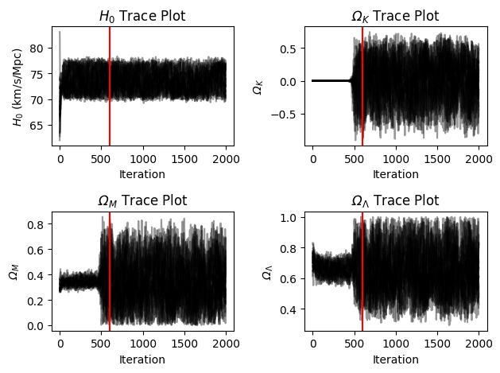

```python
fig, ax = plt.subplots(nrows=2, ncols=2)

ax[0,0].plot(sampler_b.get_chain()[:,:,0], 'k', alpha=0.4)
ax[0,0].axvline(x=600, ymin=0, ymax=1, color='red', label='burn-in point')
ax[0,0].set_xlabel("Iteration")
ax[0,0].set_ylabel("$H_0$ (km/s/Mpc)")
ax[0,0].set_title("$H_0$ Trace Plot")

ax[1,0].plot(sampler_b.get_chain()[:,:,1], 'k', alpha=0.4)
ax[1,0].axvline(x=600, ymin=0, ymax=1, color='red', label='burn-in point')
ax[1,0].set_xlabel("Iteration")
ax[1,0].set_ylabel("$\u2126_M$")
ax[1,0].set_title("$\u2126_M$ Trace Plot")

ax[0,1].plot(sampler_b.get_chain()[:,:,2], 'k', alpha=0.4)
ax[0,1].axvline(x=600, ymin=0, ymax=1, color='red', label='burn-in point')
ax[0,1].set_xlabel("Iteration")
ax[0,1].set_ylabel("$\u2126_K$")
ax[0,1].set_title("$\u2126_K$ Trace Plot")

ax[1,1].plot(sampler_b.get_chain()[:,:,3], 'k', alpha=0.4)
ax[1,1].axvline(x=600, ymin=0, ymax=1, color='red', label='burn-in point')
ax[1,1].set_xlabel("Iteration")
ax[1,1].set_ylabel("$\u2126_\u039B$")
ax[1,1].set_title("$\u2126_\u039B$ Trace Plot")

plt.tight_layout()
plt.show()
```

We can now cut out our burn-in and flatten all walkers into a singular chain for each parameter. We set our burn-in to 600 and use `get_chain()`, specifying `discard=burn_in` and `flat=True` once again.

```python
burn_in_b = 600
burned_in_b = sampler_b.get_chain(discard=burn_in_b, flat=True)
```

To visualize the parameter distributions, we use the `corner` library to plot all 1D and 2D histogram combinations of the parameters. Most of our histograms (with the exception of $H_0$) have distinct peaks. $\Omega_M$, $\Omega_K$, and $\Omega_\Lambda$ seem to have very tight relationships with each other, but not with $H_0$.

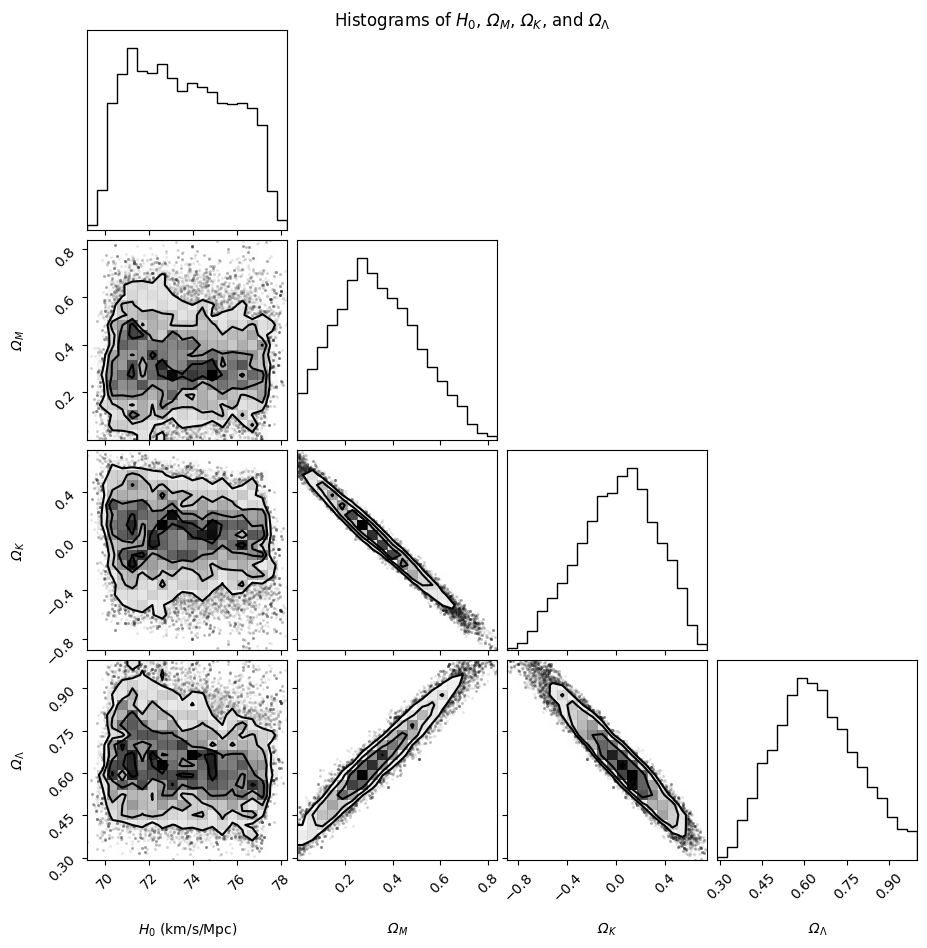

```python
fig = corner.corner(burned_in_b, labels=["$H_0$ (km/s/Mpc)", "$\u2126_M$", "$\u2126_K$", "$\u2126_\u039B$"])
fig.suptitle("Histograms of $H_0$, $\u2126_M$, $\u2126_K$, and $\u2126_\u039B$")
plt.show()
```

Next, we need to print out the median and standard deviations (or uncertainties) for each parameter. To do so, we initialized four lists, parsed out each individual parameter’s values from the MCMC output, and appended each post-burn-in chain to its respective list.

```python
h0_list_b = []
om_m_list_b = []
om_k_list_b = []
om_1_list_b = []
for i in burned_in_b:
    h0_list_b.append(i[0])
    om_m_list_b.append(i[1])
    om_k_list_b.append(i[2])
    om_1_list_b.append(i[3])
```

Using f-strings to access each list, we printed out the median and standard deviation of each parameter.

The currently accepted values of each parameter are as follows:

- $H_0\approx 72 \text{ km/s/Mpc}$ (range of 65-78)
- $Ω_M\approx 0.3$
- $Ω_K\approx 0$
- $Ω_Λ\approx 0.7$

As we can see from our median values below, all 4 of these currently accepted parameter values are pretty close to the ones that we calculated.

```python
print(f"H_0 Median: {round(np.median(h0_list_b), 3)} km/s/Mpc")
print(f"H_0 Standard Deviation: {round(np.std(h0_list_b), 3)} km/s/Mpc")
print(f"\u2126_M Median: {round(np.median(om_m_list_b), 3)}")
print(f"\u2126_M Standard Deviation: {round(np.std(om_m_list_b), 3)}")
print(f"\u2126_K Median: {round(np.median(om_k_list_b), 3)}")
print(f"\u2126_K Standard Deviation: {round(np.std(om_k_list_b), 3)}")
print(f"\u2126_\u039B Median: {round(np.median(om_1_list_b), 3)}")
print(f"\u2126_\u039B Standard Deviation: {round(np.std(om_1_list_b), 3)}")
```

```
H_0 Median: 73.43 km/s/Mpc
H_0 Standard Deviation: 2.143 km/s/Mpc
Ω_M Median: 0.323
Ω_M Standard Deviation: 0.171
Ω_K Median: 0.037
Ω_K Standard Deviation: 0.309
Ω_Λ Median: 0.636
Ω_Λ Standard Deviation: 0.144
```

Once again, and for our final plot, we randomly selected 100 sampled (post-burn-in) parameter combinations and plotted their model results back against the entirety of the data to test the fit. We also swapped the x and y axes because our dependent variable is now distance (Mpc) and our independent variable is redshift. The result is a collection of model fits that fit the data far better than those of our linear fit!

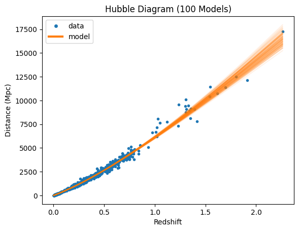

```python
legend_elements = [Line2D([0], [0], marker='o', color='white', markerfacecolor='C0', label='data'), Line2D([0], [0], color='C1', lw=3, label='model')]
plt.plot(df.z, df.d_Mpc,'.')
for i in range(100):
    index = np.random.random_integers(0,28000)
    model = calc_distance(burned_in_b[index], df.z)
    plt.plot(df.z, model, color = 'C1', alpha = 0.1)
plt.xlabel("Redshift")
plt.ylabel("Distance (Mpc)")
plt.title("Hubble Diagram (100 Models)")
plt.legend(handles=legend_elements)
plt.show()
```